# Generating more complex networks

The ER network offers what we term a "simple complex network": the simplest sort of network to exhibit complex properties. The degree distribution is simply Poisson, with the degree of every node being derived independently of every other node. The power-law network is somewhat more complicated but still follows a mathematically "clean" definition.

Real-world networks of interest are not typically not so clean. They can actually be less clean in two distinct ways. Firstly, they might exhibit specific degree distributions that aren't captured in a mathematically clean fashion, for example having no degree-2 nodes but twice as many degree-3 nodes as degree-1 nodes. In this case we may be able to describe the individual degree probabilities without being able to give a function that captures them all. Secondly, they might exhibit different degree distributions for low-degree than for high-degree nodes. A typical example is where a distribution is flat at low degree with a power-law "tail". In this case we want to be able to glue degree distributions together in a way that still allows analysis and simulation.

## Networks with specific degree distributions

When we built an ER network we did so by specifying a generating process and then examining the resulting graph, analytically and in simulation, to derive its degree distribution. Sometimes this is the appropriate approach, and works well when the growth process is the object of study: given this process, what networks arise? These situations frequently occur in experimental science.

There is also the reverse approach, however: given a particular degree distribution, generate a random network whose node degrees have that distribution. This approach can be used to study theoretical results for graphs with different distributions, or to generate the random counterparts of networks whose degree distributions have been collected in the field and for which we may not know the appropriate generating process. This is sometimes called the *configuration model*, and is the approach we will focus on in this chapter, since it allows us to generate networks with *arbitrary* degree distributions, not simply those for which we understand the generating process. Another way to look at this is that we can define a *generic generating process* that can be parameterised by the degree distribution we want.

### Describing the distribution

Continuous probability distributions are typically given by probability density or cumulative probability functions. However, for networks, the degree distribution is necessarily discrete: all possible degrees of a node are non-negative integers. Therefore the correct way to work with degree distributions is using [probability mass functions](https://en.wikipedia.org/wiki/Probability_mass_function): if $P$ is a probability mass function, then $P(X = k)$ is the probability that a random variable $X$ drawn from the distribution has value $k$, where $k$ is an integer and where $P$ is properly normalised so that $\sum_k P(k) = 1$. It is often the case that there is a largest possible value of $k$, $k_{max}$, such that $P(X = k) = 0$ for all $k > k_{max}$. $P(X = k)$ can be defined as a function (*i.e.*, as a closed-form expression for any integer value of $k$) or given piecemeal where $k_{max}$ is finite simply by listing the component probabilities.

The closed-form case is exemplified by the ER network description we derived earlier:

$$P(deg(v) = k) = \frac{(N\phi)^k e^{-N\phi}}{k!}$$

In this case there is no $k_{max}$: any value of $k$ is possible, although the probability that a value will appear drops-off rapidly as we move away from the mean degree $\langle k \rangle = N\phi$.

For the piecemeal case we can specify the probability for each value of $k$ in the legal range, $0 \leq k \leq k_{max}$. The individual probabilities must sum to $1$ for the sequence to be a valid probability distribution.

### Drawing from the distribution

Given a probability distribution, we now need to be able to draw values from it. That is to say, we want to be able to generate a sequence of numbers that exhibit the distribution described by the closed-form or piecemeal description. How do we do this? How do we generate a set of random numbers with a given distribution?

There is a standard technique for accomplishing this called the *Monte Carlo method*, named after the city-state in southern Europe famous for its casinos. The Monte Carlo approach relies on the availability of a source of uniformly distributed random numbers, and from these can generate a sequence of numbers conforming to *any* desired distribution.

Python's random number function `numpy.random.random()` generates uniformly-distributed random numbers in the range $[0 \ldots 1]$ and so can used as the basis for the technique.

```python
# NetworkX for network representation
import networkx as nx

# Some handy mathematical functions
import math

# Random numbers from numpy
import numpy as np
import numpy.random as rnd

# Data anlysis with pandas
import pandas as pd

# Important elements of matplotlib
import matplotlib.pyplot as plt
import matplotlib.colors as clr
import matplotlib.cm as cmx

# Plot all graphics in-line in the notebook
%matplotlib inline
```

To create the set of numbers, we repeatedly do the following:

1. Generate a random number in the range $[0 \ldots 1]$
2. Scale this number up across the values we want to consider. Call this value $k$
3. Compute $p_{k} = P(deg(v) = k)$ from the distribution
4. Generate another random number in the range $[0 \ldots 1]$. Call this value $a$
5. If $a \leq p_{k}$ we *accept* $k'$ as a value; otherwise we *reject* it

We continue this process until we have a set of numbers of the appropriate size $N$.

Rather than generate a list of numbers, which might be very large, we will instead construct a Python class representing a dataset of numbers drawn from an arbitrary distribution.

```python
class Dataset(object):
    """Represent a dataset of numbers drawn from an underlying distribution"""

    """Initialise to a dataset of size n"""
    def __init__( self, n ):
        self._n = n
        self._gen = 0

    def __iter__( self ):
        """Use ourselves as the iterator"""
        return self

    def next( self ):
        """Return the next element from the dataset"""
        if self._gen >= self._n:
            raise StopIteration
        else:
            v = self.candidate()
            if rnd.random() < self.probabilityOf(v):
                self._gen = self._gen + 1
                return v
            else:
                return self.next()

    def values( self ):
        """Return a list of all the elements remaining in the dataset. Typically
        used instead of iterating"""
        vs = []
        for v in self:
            vs.append(v)
        return vs
```

We make a class an iterator, allowing its values to be generated as required. The distribution is specified by sub-classing and providing two methods, `candidate()` and `probabilityOf()` which respectively generate a "candidate" value to be included in the dataset and the probability of a value occurring. The `next()` method encapsulates the Monte Carlo process, generating a candidate value and either accepting or rejecting it according to the value's probability of occurring.

To define a dataset for an arbitrary distributions we first need an exception to be raised if we provide a probability mass function that is incorrect in any way:

```python
class InvalidDistribution(Exception):
    """Exception raised when we encounter an invalid probability distribution"""

    def __init__( self, msg ):
        self.message = msg

    def __str__( self ):
        return "Invalid distribution: " + self.message
```

We can then define a dataset that generates values according to a probability mass function, which is specified by providing the probabilities of each value occurring:

```python
class DiscreteDataset(Dataset):
    """Represent a dataset drawn against a given probability mass function"""

    # a value small enough that statistical errors of this magnitude
    # don't matter: one in a billion, by default
    _eps = 1.0e-9

    def __init__( self, n, dist ):
        """Initalise the dataset with the given discrete probabilities, to
        generate values in the range [0 ... len(dist) - 1]"""
        super(DiscreteDataset, self).__init__(n)

        # check given distribution is properly normalised
        if abs(1.0 - sum(dist)) < self._eps:
            self._dist = dist
        else:
            raise InvalidDistribution("Component probabilities do not sum to 1")

    def candidate( self ):
        """Generate a candidate value in the range [0 ... len(dist) - 1]"""
        return int(rnd.random() * len(self._dist))

    def probabilityOf( self, v ):
        """The probability of a value appearing is taken directly from the
        probability mass function"""
        return self._dist[v]
```

We check that the distribution is normalised before use. (The `eps` calculation is necessary because floating-point calculations are not precise. Suppose we tried to build a dataset corresponding to tosses of a die using `DiscreteDataset(1/6.0, 1/6.0, 1/6.0, 1/6.0, 1/6.0, 1/6.0)`: without the possibility of a small error, this distribution would fail because the component probabilities might not *quite* add up to `1.0`.)

We can check that the dataset generates values according to the probability mass function by histogramming:

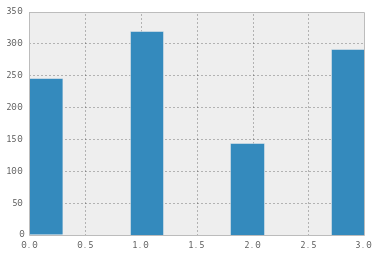

```python
d = DiscreteDataset(1000, [ 0.25, 0.3, 0.15, 0.3 ])
plt.hist(d.values())
plt.show()
```

These values seem close enough to the "true" probabilities.

### Generating the network: the configuration model

In order the generate a network with the given degree distribution, we need to make use the the Monte Carlo method to create a set of nodes with the desired degrees. This again differs from the ER generator used before: rather then use a generating process that creates edges with a given degree distribution (Poisson in that case), we will instead generate the node degrees and then use these as the basis for creating the edges we need. In other words we *start* with the node degrees and *induce* the edges, rather than the other way round.

The technique is to create a set of nodes with edge "stubs" corresponding to the desired degree. We created these stubs using the desired degree distribution, drawing for each node a number from the distribution and creating that many stubs on the node. It is easy to see that this gives the right distribution of edge stubs. We then connect the edge stubs of pairs of nodes randomly, yielding a random graph with the desired degree distribution. (One small limitation is that the sum of the degree distributions has to be even, since each edge requires two edge stubs.)

We can encapsulate this as a single function for building a graph whose node degrees are taken from a dataset drawn from an arbitrary distribution:

```python
def discrete_graph( dist ):
    """Generate a graph with node degrees taken from the given dataset"""

    # create the empty graph
    g = nx.Graph()

    # populate the graph with nodes, capturing the number of edge stubs
    # desired on each
    i = 0
    ws = []
    dsum = 0
    for dd in dist:
        v = g.add_node(i)
        if dd > 0:
            ws.append((i, dd))
            i = i + 1
            dsum = dsum + dd

    # if the sum of degrees is odd, bump the degree of a random node
    # (the assumption being that this will make little difference)
    if dsum % 2 <> 0:
        i = int(rnd.random() * len(ws))
        (v, d) = ws[i]
        ws[i] = (v, d + 1)

    # wire-up edges between random nodes according to the remaining edge stubs
    while len(ws) > 1:
        si = int(rnd.random() * len(ws))
        ei = si
        while ei == si:
            # avoid self-loops
            # sd: should we do this or not?
            ei = int(rnd.random() * len(ws))

        # add edge between chosen nodes
        (s, ss) = ws[si]
        (e, es) = ws[ei]
        g.add_edge(s, e)

        # reduce the edge stubs on both nodes
        if ss > 1:
            ws[si] = (s, ss - 1)
        else:
            ws.pop(si)
            if si < ei:
                ei = ei - 1
        if es > 1:
            ws[ei] = (e, es - 1)
        else:
            ws.pop(ei)

    # if we have a node left, forget it (the assumption being that
    # a deviation 1 from the distribution won't matter, which is true
    # for networks of thousands of nodes or more at least)

    return g
```

We can now use this function to build a graph with an arbitrary degree distribution given by a probability mass function using our `DiscreteDataset` class:

```python
g = discrete_graph(DiscreteDataset(100, [ 0.25, 0.3, 0.15, 0.3 ]))
```

We can draw this graph to at least get an idea of how it is wired up:

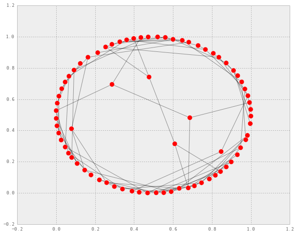

```python
plt.figure(figsize=(10, 8))

# run the spring layout algorithm over the network
pos = nx.spring_layout(g, iterations = 100, k = 2/math.sqrt(g.order()))

# draw the network using the computed positions for the nodes
nx.draw_networkx_edges(g, pos, width = 1, alpha = 0.4)
nx.draw_networkx_nodes(g, pos, node_size=100, alpha = 1, linewidths = 0.5)
plt.show()
```

Just to show that the approach works for *any* distribution, we can define a dataset sub-class that represents the Poisson distribution. Generating this graph should yield an ER network the same as was acquired using the earlier generating process – except now we start from the degree distribution and generate the network using a standard process, rather than starting with a generating process that results in nodes with Poisson degree:

```python
class PoissonDataset(Dataset):
    """Represent a dataset drawn against a Poisson distribution"""

    def __init__( self, n, k ):
        """Initalise the dataset with the given size and mean degree"""
        super(PoissonDataset, self).__init__(n)
        self._meanDegree = k

    def candidate( self ):
        """Generate a candidate value"""
        return int(rnd.random() * self._meanDegree * 2)

    def probabilityOf( self, v ):
        """The probability of a value appearing is taken from the
        binomial distribution"""
        return (pow(self._meanDegree, v) * math.exp(-self._meanDegree)) / math.factorial(v)
```

We can generate an ER network with 1000 nodes and mean degree 5 using:

```python
g = discrete_graph(PoissonDataset(1000, 5))
```

Plotting this graph isn't particularly informative due to the density of information:

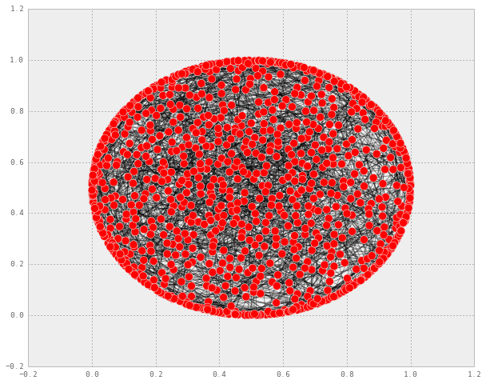

```python
plt.figure(figsize=(10, 8))

# run the spring layout algorithm over the network
pos = nx.spring_layout(g, iterations = 100, k = 2/math.sqrt(g.order()))

# draw the network using the computed positions for the nodes
nx.draw_networkx_edges(g, pos, width = 1, alpha = 0.4)
nx.draw_networkx_nodes(g, pos, node_size=100, alpha = 1, linewidths = 0.5)
plt.show()
```

However, we can plot the degree distribution to check that it looks Poisson:

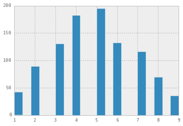

```python
plt.hist(g.degree().values(), bins = 20)
plt.show()
```

This approach to generating a network is called the *configuration model*.

### Neighbours and degrees

The configuration model works using the idea of "stubs" that become edges, with each stub being equally likely to be connected to any other stub. If we sum-up the degrees of all the $N$ nodes in a network, we get the number of stubs, which itself is twice the number of edges in the network (since each edge connects two stubs). If the network has $M$ edges – so $M = \sum_v deg(v)$ \ndash; then there will be $2M$ stubs. Another way to say the same thing is that $2M = \langle k \rangle N$.

Suppose we have two nodes $i$ and $j$. What is the probability that there is an edge between them?

Let the degrees of $i$ and $j$ be denoted $k_i$ and $k_j$ respectively. Pick a stub on $i$. There are $2M - 1$ stubs in the network, excluding this one. Of these $2M - 1$ stubs, $k_j$ of them are on node $j$. Since every stub is equally likely to connect to any other stub, the probability that the stub we've chosen on node $i$ gets connected to node $j$ is $\frac{k_j}{2M - 1}$. Since there are $k_i$ possible stubs on node $i$ for which we can make this same argument, the probability that nodes $i$ and $k$ are connected is $\frac{k_i k_j}{2M - 1} \approx \frac{k_i k_j}{\langle k \rangle N}$.

## Generating functions

Probability mass functions, and indeed other ways of specifying a probability distribution, are structured around the treatment of individual values in a distribution. While this is an essential part of a distribution, it is not the only factor of interest. Typically we are interested in a distribution's summary statistics – its mean and variance – and perhaps in other structures within it. If the distribution represents the degrees of nodes in a network, we are interested not simply in the nodes themselves, but in what other structures arise as a result. In particular we may be interested in the formation of connected components of nodes, or in questions like: if we pick a random node, what are the likely degrees of its neighbours? While these properties aree immanent in the probability distribution, it is not immediately clear how they relate to it, especially in the case of networks with arbitrary degree distribution.

Fortunately there is a way of representing a distribution that makes higher-order structures far easier to extract. This method has become very popular in the network science literature, and enormously simplifies the analysis and manipulation of degree distributions.

[Generating functions](https://en.wikipedia.org/wiki/Generating_function) are a mathematical device for encapsulating a collection of individual discrete probabilities into a single compound function. Wilf [Wil90] describes them as "a clothes line on which to hang a series": they are somewhat related to [Taylor series](https://en.wikipedia.org/wiki/Taylor_series), which (I was delighted to discover in the course of writing this) themselves originate in the work of another St Andrews academic, [James Gregory](https://en.wikipedia.org/wiki/James_Gregory_%28astronomer_and_mathematician%29).

### Construction

In discussing probability mass functions above, we represented the distribution as $\sum_k p_k$ where $p_k$ is the probability of the integer value $k$ appearing in the distribution. To represent this as a [probability generating function](https://en.wikipedia.org/wiki/Probability-generating_function), we take the series $p_k$ construct a function $G_0$ of the form:

$$G_0(x) = \sum_k p_k x^k$$

In this function, $x$ is simply a parameter that runs from $0$ to $1$. The distribution has to be properly normalised, so $\sum_k p_k = 1$. In some circumstances we may have measurements for the number of nodes $N_k$ for each degree $k$. In this case we can rephrase the definition to give:

$$G_0(x) = \frac{\sum_k N_k x^k}{\sum_k N_k}$$

where the denominator normalises the distribution by dividing by the number of nodes in the network and $\sum_k N_k = N$ by definition.

### Extremal values

This seems like a strange sort of equation that leads to all kinds of questions: where do the powers of $x$ come from, and what does $x$ – and indeed $G_0$ itself – represent at all? The answers to these questions are not at all obvious.

Firstly, let is deal with $x$ by looking at the extremal values. If we evaluate $G_0$ at $x = 0$ we find:

$$ \begin{align*} G_0(0) &= \sum_k p_k x^k \\ &= \sum_k p_k 0^k \\ &= p_0 \cdot 1 + p_1 \cdot 0 + p_2 \cdot 0 \ldots \\ &= p_0 \end{align*} $$

So $G_0(0) = P(X = 0)$, the probability that $X = 0$ or, in our case, that the distribution contains disconnected nodes. At the other extreme,

$$ \begin{align*} G_0(1) &= \sum_k p_k 1^k \\ &= \sum_k p_k \\ &= 1 \end{align*} $$

$G_0(1)$ is $1$ by definition, since it is the sum of all the component probabilities.

What about intermediate values of $x$? We'll *never use them*.

A generating function is what's termed a *formal power series*. That is to say, it combines information together using powers of a parameter, but is never intended to be generally evaluated. Instead, it's intended as an encoding to be *manipulated*, and the encoding is such that it allows some simple operations to be performed that would otherwise be complicated with other encodings.

### Retrieving the component probabilities

Suppose we have $G_0(x)$ and want to retrieve the component probabilities: that is to say, we want to extract $p_0$, $p_1$ and so on. We can observe that evaluating $G_0(x)$ extracted the leftmost value of $p_k$, so we need to "shift the function left". Given that each term in $G_0$ is an integer power of $x$, differentiating will perform this operation:

$$ \begin{align*} G_0'(x) &= \frac{d}{dx} G_0(x) \\ &= \frac{d}{dx} \sum_k p_k x^k \\ &= \sum_k \frac{d}{dx} p_k x^k \\ &= \sum_k k p_k x^{k - 1} \\ &= p_1 + 2 p_2 x + 3 p_3 x^2 + 4 p_4 x^3 + \ldots \end{align*} $$

(The value of $p_0$ is dropped, since it is a constant, being multiplied by $x^0 = 1$ for all $x$.) So if evaluating $G_0'(0)$ will return $p_1$. What is we want $p_2$? Differentiating again we get:

$$ \begin{align*} G_0''(x) &= \frac{d}{dx} G_0'(x) \\ &= \sum_k \frac{d}{dx} k p_k x^{k - 1} \\ &= 2 p_2 + 6 p_3 x + 12 p_4 x^2 + \ldots \end{align*} $$

Now we have $G_0''(0) = 2 p_2 = k p_2$. Extracting $p_3$, we find:

$$ \begin{align*} G_0^{(3)}(x) &= \frac{d}{dx} G_0''(x) \\ &= \sum_k \frac{d}{dx} k p_k x^{k - 1} \\ &= 6 p_3 + 24 p_4 x + \ldots \end{align*} $$

$G_0^{(3)}(0) = 6 p_3 = k(k - 1) p_3$, $G_0^{(4)}(0) = 24 p_4 = k(k - 1)(k - 2) p_4$, and so forth. Continue this for a few more elements and it becomes clear that the multiplie for $p_k$ is $k!$, which means that in general:

$$p_k = \frac{1}{k!} \frac{d^k}{dx^k} G_0(x) \bigg|_{x = 0} = \frac{1}{k!} G_0^{(k)}(0)$$

So we can retrieve $p_k = P(X = k)$ by differentiating $G_0(x)$ $k$ times and evaluating at $x = 0$. This shows that the generating function encodes all the information about the probability distribution, and that we can retrieve it if required. In computer science terms, the generating function is just an encoding of the probability mass function – an encoding of a sequence as a single function. As such it would simply be an encoding like any other, were it not for other properties of this *particular* encoding that make it suitable for working with degree distributions, to which we will now turn.

### Summary statistics

The next useful property of the generating function is that we can use it to extract summary statistics directly. The mean of the distribution – also called the *first moment* – which corresponds to the mean degree $\langle k \rangle$, is given (in expectation form) by:

$$\langle k \rangle = \mathbb{E}(k) = \sum_k k \, p_k$$

Looking back to the differentiation above, we has an intermediate term where we defined $G_0'(x) = \sum_k k p_k x^{k - 1}$, which we evaluated at $x = 0$ to extract the leading term by dropping all the higher powers of $x$: all the terms that include a power of $x$ are dropped, since $0^k = 0$ for all $k$. If instead we wanted to include all the terms, we could simply evaluate at $x = 1$, so all those powers of $x$ become $1$. This means that

$$\langle k \rangle = G_0'(1)$$

Higher moments (which are sometimes needed) can be calculated by further differentiation:

$$\langle k^n \rangle = \sum_k k^n \, p_k = \bigg [ \bigg ( x \frac{d}{dx} \bigg )^n G_0(x) \bigg ]_{x = 1}$$

Finally, it turns out that a generating function has a "powers" property, that if we have some property $a$ that is also generated by $G_0$ (which implies that it has the same probability distribution as node degree), then the distribution of $a$ taken over $m$ independent realisations is given by the $m$th power of $G_0$.

### The generating functions for ER and power law networks

$$p_k = \binom{N}{k} \phi^k (1 - \phi)^{N - k}$$

for an edge probability of $\phi$. We can therefore construct the generating function by substituting this equation into the general equation above, to get:

$$ \begin{align*} G_0(x) &= \sum_k \binom{N}{k} \phi^k (1 - \phi)^{N - k} x^k \\ &= (1 - \phi + \phi x)^N \\ &\approx e^{\langle k \rangle(x - 1)} \end{align*} $$

for large graphs ($N \rightarrow \infty$).

Extracting the mean degree from the generating function involves evaluating $G_0'(1)$. We therefore have:

$$ \begin{align*} \frac{d}{dx} G_0(x) \bigg |_{x = 1} &= \bigg ( \frac{d}{dx} {\langle k \rangle (x - 1)} \bigg ) e^{\langle k \rangle(x - 1)} \bigg |_{x = 1} \\ &= \langle k \rangle e^{\langle k \rangle(x - 1)} \bigg |_{x = 1} \\ &= \langle k \rangle \end{align*} $$

What about for a power law network? In this case we have that $P(deg(v) = k) = C \, k^{-\alpha}$ where $C = \frac{1}{\zeta(\alpha, 1)}$, and the corresponding generating function is therefore:

$$ G_0(x) = C \sum_{k} k^{-\alpha} x^k $$

This sum is an example of another "special" function, a [polylogarithm](https://en.wikipedia.org/wiki/Polylogarithm) of order $\alpha$. Polylogarithms also turn up in quantum physics. Unfortunately they don't have a convenient general representation, and we won't deal with them any further.

### The degree distribution of neighbouring nodes

Suppose we choose a node $v$ from a graph, and then follow a randomly-chosen edge $e$ to another node $w$: what would we expect the degree of $w$ to be?

One might naïvely think that the the degree of $w$ will be the mean degree of the network, $\langle k \rangle$. However, we have to account for the possibility that we may pick a node with a higher-than-average degree, which will in turn have more possible variations of neighbours than a node with lower-than-average degree. A degree-1 node only has one way to get to a neighbour, but a degree-2 node has twice as many ways, and therefore twice as many options for the degrees of its neighbours.

What is the probability of particular node being adjacent to a node of degree $k$? If we select a particular stub on the node, then there are $\langle k \rangle N - 1$ other stubs in the network it could attach to. Exactly $k$ of these stubs are attached to some *particular* node of degree $k$, so the probability of the initial node being adjacent to that *particular* node is $\frac{k}{\langle k \rangle N - 1}$. There are $N \, P(deg(v) = k)$ nodes of degree $k$ in the network overall, so the probability of the initial node being adjacent to *any* node of degree $k$ is:

$$ \frac{k}{\langle k \rangle N - 1} N \, P(deg(v) = k) \approx \frac{k \, P(deg(v) = k)}{\langle k \rangle} $$

If we take this equation and combine it for all values of $k$, we can create a generating function for the expected degree of neighbouring nodes.

Firstly, $e$ arrives at $w$ with a probability proportional to $w$'s degree (since there are that many ways to arrive at $w$), and so $w$'s degree distribution will be proportional to $k p_k$. Expressed in terms of generating functions, the distribution of degrees of the neighbouring vertices is given by $x \frac{G_0'(x)}{G_0'(1)}$. Taken as a whole, if we start at $v$ and visit all $k$ neighbouring vertices, the degree distribution of these vertices is given by this function less one power of $x$ (to account for the edge we traversed to arrive from $v$). Therefore the generating function $G_1$ for the degree distribution of the neighbouring nodes of a randomly-chosen node is given by:

$$G_1(x) = \frac{G_0'(x)}{G_0'(1)} = \frac{1}{\langle k \rangle} G_0'(x)$$

since $G_0'(1) = \langle k \rangle$. The "powers" property from above means that we can iterate this approach. The generating function for second neighbours is given by:

$$G_2(x) = \sum_k p^k [ G_1(x) ]^k = G_0(G_1(x))$$

and generally the distribution of $m$ neighbours is given by:

$$ G_0^{(m)}(x) = \bigg \{ \begin{array}{ll} G_0(x) & \mathrm{if~} m = 1 \\ G_0^{(m - 1)}(G_1(x)) & \mathrm{if~} m \geq 2 \end{array} $$

(The 1st neighbours are exactly the same to the degree of a node, given by $G_0(x)$, on the assumption that there are no self-loops. Since the probability of a node linking to itself is $O(n^{-1})$ we can safely ignore it in large graphs as $N \rightarrow \infty$.)

From this we can work out the average number of second neighbours and so on (*i.e.*, the average degree of a node conneted to a randomly-chosen node) as:

$$\langle k^2 \rangle = \frac{d}{dx} G_1(x) \bigg |_{x = 1} = G_1'(1) \langle k \rangle$$

and in general that the average number of $m$th neighbours is given by:

$$\langle k^m \rangle = \bigg ( \frac{\langle k^2 \rangle}{\langle k \rangle} \bigg )^{m - 1} \langle k \rangle$$

It is worth remembering that, for most large random graphs, we can make a *large graph approximation* that $N \gg \langle k \rangle$ and $\langle k^2 \rangle \gg \langle k \rangle$.

### Components

A network will typically have zero or more *components*, in which all nodes are reachable from all others by following some path of edges through the cluster. We can use the generating functions of the degree distribution, and the other structures derived from them, to work out the distribution of cluster sizes in networks with different degree structures.

We can phrase this in a similar way to the way we phrased the degree distribution of neighbours above: if we follow an edge at random to a node $w$, what is the probability distribution of the cluster to which $w$ belongs? We'll refer to this function as $H_1(x)$, by analogy to the earlier functions: $G_0(x)$ is the generating function for edges at a node, $G_1(x)$ the distribution of the edges of nodes that are neighbours of a randomly-chosen node, $G_2(x)$ the distribution of edges on second-neighbours, and so on. $H_1(x)$ is the distribution of the clusters to which neighbouring nodes may belong.

Think about what happens as we follow $e$. We end up at a node $w$ that has degree at least $1$ (since we traversed $e$ to reach it. It may have no neighbours, or it may have neighbours which themselves have neighbours and so on. In the absence of loops we can imagine these neighbours as forming a tree whose branches are all the neighbouring nodes of $w$ except the one attached to $e$ down which we arrived.

In terms of probabilities, let $q_k$ denote the probability that $w$ has $k$ neighbours *excluding the one we came from*. This probability is generated by $G_1(x)$, since it is the probability of the degree of a neighbour of a randomly-chosen node.

### Shortest paths

Another useful property of a graph is the average shortest path between two randomly-chosen nodes.

We can consider this problem in terms of the number of nodes encountered as we follow a path. From the starting node we traverse a random edge (one of $\langle k \rangle$) and encounter another node, which in turn has $\langle k^2 \rangle$ neighbours, and so on. If we continue this process, keeping track of how many neighbouring nodes we encounter as we go (and ignoring the possibility of loops as mentioned above), then eventually the total number of nodes encountered will equal the number of nodes in the graph, and there will therefore have been a path between the initial node and any other node of about half this length. The shortest path $l$ is therefore found by solving:

$$1 + \sum_{m = 1}^{l} \langle k^m \rangle = N$$

Using the large-graph approximation we can reduce this to:

$$l \approx 1 + \frac{log(\frac{N}{\langle k \rangle})}{log (\frac{\langle k^2 \rangle}{\langle k \rangle})} \approx \frac{log N}{log \langle k^2 \rangle}$$

## Summary

- $G_0(x)$ – generating function for node degrees
- $G_0^{(k)}(0)$ – probability of a node of degree $k$
- $G_0'(1)$ – average degree distribution $\langle k \rangle$
- $G_1(x)$ – generating function for degrees of first neighbours of a randomly-chosen node